# Risk Factor Analysis

## Outcome Variable

**Outcome Variable:** ever_wasted

## Predictor Variables

**Intervention Variable:** single

**Adjustment Set:**

- arm
- W_mage
- meducyrs
- feducyrs
- W_mhtcm
- W_mwtkg
- W_mbmi
- delta_W_mage
- delta_meducyrs
- delta_feducyrs
- delta_W_mhtcm
- delta_W_mwtkg
- delta_W_mbmi

## Stratifying Variables

The analysis was stratified on these variable(s):

- agecat
- studyid
- country

## Data Summary

| agecat | studyid | country | single | ever_wasted | n_cell | n |
| --- | --- | --- | --- | --- | --- | --- |
| 0-24 months | COHORTS | GUATEMALA | 0 | 0 | 804 | 1197 |
| 0-24 months | COHORTS | GUATEMALA | 0 | 1 | 295 | 1197 |
| 0-24 months | COHORTS | GUATEMALA | 1 | 0 | 77 | 1197 |
| 0-24 months | COHORTS | GUATEMALA | 1 | 1 | 21 | 1197 |
| 0-24 months | COHORTS | INDIA | 0 | 0 | 3568 | 5376 |
| 0-24 months | COHORTS | INDIA | 0 | 1 | 1799 | 5376 |
| 0-24 months | COHORTS | INDIA | 1 | 0 | 5 | 5376 |
| 0-24 months | COHORTS | INDIA | 1 | 1 | 4 | 5376 |
| 0-24 months | COHORTS | PHILIPPINES | 0 | 0 | 1754 | 3005 |
| 0-24 months | COHORTS | PHILIPPINES | 0 | 1 | 1177 | 3005 |
| 0-24 months | COHORTS | PHILIPPINES | 1 | 0 | 41 | 3005 |
| 0-24 months | COHORTS | PHILIPPINES | 1 | 1 | 33 | 3005 |
| 0-24 months | Guatemala BSC | GUATEMALA | 0 | 0 | 225 | 282 |
| 0-24 months | Guatemala BSC | GUATEMALA | 0 | 1 | 27 | 282 |
| 0-24 months | Guatemala BSC | GUATEMALA | 1 | 0 | 27 | 282 |
| 0-24 months | Guatemala BSC | GUATEMALA | 1 | 1 | 3 | 282 |
| 0-24 months | JiVitA-4 | BANGLADESH | 0 | 0 | 3734 | 5424 |
| 0-24 months | JiVitA-4 | BANGLADESH | 0 | 1 | 1682 | 5424 |
| 0-24 months | JiVitA-4 | BANGLADESH | 1 | 0 | 7 | 5424 |
| 0-24 months | JiVitA-4 | BANGLADESH | 1 | 1 | 1 | 5424 |
| 0-24 months | MAL-ED | BANGLADESH | 0 | 0 | 176 | 263 |
| 0-24 months | MAL-ED | BANGLADESH | 0 | 1 | 87 | 263 |
| 0-24 months | MAL-ED | BANGLADESH | 1 | 0 | 0 | 263 |
| 0-24 months | MAL-ED | BANGLADESH | 1 | 1 | 0 | 263 |
| 0-24 months | MAL-ED | BRAZIL | 0 | 0 | 182 | 233 |
| 0-24 months | MAL-ED | BRAZIL | 0 | 1 | 15 | 233 |
| 0-24 months | MAL-ED | BRAZIL | 1 | 0 | 31 | 233 |
| 0-24 months | MAL-ED | BRAZIL | 1 | 1 | 5 | 233 |
| 0-24 months | MAL-ED | INDIA | 0 | 0 | 130 | 249 |
| 0-24 months | MAL-ED | INDIA | 0 | 1 | 119 | 249 |

[output cut: 150 more lines]

The following strata were considered:

- agecat: 0-24 months, studyid: COHORTS, country: GUATEMALA
- agecat: 0-24 months, studyid: COHORTS, country: INDIA
- agecat: 0-24 months, studyid: COHORTS, country: PHILIPPINES
- agecat: 0-24 months, studyid: Guatemala BSC, country: GUATEMALA
- agecat: 0-24 months, studyid: JiVitA-4, country: BANGLADESH
- agecat: 0-24 months, studyid: MAL-ED, country: BANGLADESH
- agecat: 0-24 months, studyid: MAL-ED, country: BRAZIL
- agecat: 0-24 months, studyid: MAL-ED, country: INDIA
- agecat: 0-24 months, studyid: MAL-ED, country: NEPAL
- agecat: 0-24 months, studyid: MAL-ED, country: PERU
- agecat: 0-24 months, studyid: MAL-ED, country: SOUTH AFRICA
- agecat: 0-24 months, studyid: MAL-ED, country: TANZANIA, UNITED REPUBLIC OF
- agecat: 0-24 months, studyid: PROBIT, country: BELARUS
- agecat: 0-24 months, studyid: TanzaniaChild2, country: TANZANIA, UNITED REPUBLIC OF
- agecat: 0-24 months, studyid: ZVITAMBO, country: ZIMBABWE
- agecat: 0-6 months, studyid: COHORTS, country: GUATEMALA
- agecat: 0-6 months, studyid: COHORTS, country: INDIA
- agecat: 0-6 months, studyid: COHORTS, country: PHILIPPINES
- agecat: 0-6 months, studyid: Guatemala BSC, country: GUATEMALA
- agecat: 0-6 months, studyid: JiVitA-4, country: BANGLADESH
- agecat: 0-6 months, studyid: MAL-ED, country: BANGLADESH
- agecat: 0-6 months, studyid: MAL-ED, country: BRAZIL
- agecat: 0-6 months, studyid: MAL-ED, country: INDIA
- agecat: 0-6 months, studyid: MAL-ED, country: NEPAL
- agecat: 0-6 months, studyid: MAL-ED, country: PERU
- agecat: 0-6 months, studyid: MAL-ED, country: SOUTH AFRICA
- agecat: 0-6 months, studyid: MAL-ED, country: TANZANIA, UNITED REPUBLIC OF
- agecat: 0-6 months, studyid: PROBIT, country: BELARUS
- agecat: 0-6 months, studyid: TanzaniaChild2, country: TANZANIA, UNITED REPUBLIC OF
- agecat: 0-6 months, studyid: ZVITAMBO, country: ZIMBABWE
- agecat: 6-24 months, studyid: COHORTS, country: GUATEMALA
- agecat: 6-24 months, studyid: COHORTS, country: INDIA
- agecat: 6-24 months, studyid: COHORTS, country: PHILIPPINES
- agecat: 6-24 months, studyid: Guatemala BSC, country: GUATEMALA
- agecat: 6-24 months, studyid: JiVitA-4, country: BANGLADESH
- agecat: 6-24 months, studyid: MAL-ED, country: BANGLADESH
- agecat: 6-24 months, studyid: MAL-ED, country: BRAZIL
- agecat: 6-24 months, studyid: MAL-ED, country: INDIA
- agecat: 6-24 months, studyid: MAL-ED, country: NEPAL
- agecat: 6-24 months, studyid: MAL-ED, country: PERU
- agecat: 6-24 months, studyid: MAL-ED, country: SOUTH AFRICA
- agecat: 6-24 months, studyid: MAL-ED, country: TANZANIA, UNITED REPUBLIC OF
- agecat: 6-24 months, studyid: PROBIT, country: BELARUS
- agecat: 6-24 months, studyid: TanzaniaChild2, country: TANZANIA, UNITED REPUBLIC OF
- agecat: 6-24 months, studyid: ZVITAMBO, country: ZIMBABWE

### Dropped Strata

Some strata were dropped due to rare outcomes:

- agecat: 0-24 months, studyid: COHORTS, country: INDIA
- agecat: 0-24 months, studyid: Guatemala BSC, country: GUATEMALA
- agecat: 0-24 months, studyid: JiVitA-4, country: BANGLADESH
- agecat: 0-24 months, studyid: MAL-ED, country: BANGLADESH
- agecat: 0-24 months, studyid: MAL-ED, country: INDIA
- agecat: 0-24 months, studyid: MAL-ED, country: NEPAL
- agecat: 0-24 months, studyid: MAL-ED, country: TANZANIA, UNITED REPUBLIC OF
- agecat: 0-6 months, studyid: COHORTS, country: INDIA
- agecat: 0-6 months, studyid: Guatemala BSC, country: GUATEMALA
- agecat: 0-6 months, studyid: JiVitA-4, country: BANGLADESH
- agecat: 0-6 months, studyid: MAL-ED, country: BANGLADESH
- agecat: 0-6 months, studyid: MAL-ED, country: BRAZIL
- agecat: 0-6 months, studyid: MAL-ED, country: INDIA
- agecat: 0-6 months, studyid: MAL-ED, country: NEPAL
- agecat: 0-6 months, studyid: MAL-ED, country: PERU
- agecat: 0-6 months, studyid: MAL-ED, country: TANZANIA, UNITED REPUBLIC OF
- agecat: 6-24 months, studyid: COHORTS, country: INDIA
- agecat: 6-24 months, studyid: Guatemala BSC, country: GUATEMALA
- agecat: 6-24 months, studyid: JiVitA-4, country: BANGLADESH
- agecat: 6-24 months, studyid: MAL-ED, country: BANGLADESH
- agecat: 6-24 months, studyid: MAL-ED, country: BRAZIL
- agecat: 6-24 months, studyid: MAL-ED, country: INDIA
- agecat: 6-24 months, studyid: MAL-ED, country: NEPAL
- agecat: 6-24 months, studyid: MAL-ED, country: PERU
- agecat: 6-24 months, studyid: MAL-ED, country: TANZANIA, UNITED REPUBLIC OF

## Methods Detail

We're interested in the causal parameters $E[Y_a]$ for all values of $a \in \mathcal{A}$. These parameters represent the mean outcome if, possibly contrary to fact, we intervened to set all units to have $A=a$. Under the randomization and positivity assumptions, these are identified by the statistical parameters $\psi_a=E_W[E_{Y|A,W}(Y|A=a,W)]$. In addition, we're interested in the mean of $Y$, $E[Y]$ under no intervention (the observed mean). We will estimate these parameters by using SuperLearner to fit the relevant likelihood factors -- $E_{Y|A,W}(Y|A=a,W)$ and $p(A=a|W)$, and then updating our likelihood fit using a joint TMLE.

For unadjusted analyses ($W=\{\}$), initial likelihoods were estimated using Lrnr_glm to estimate the simple $E(Y|A)$ and Lrnr_mean to estimate $p(A)$. For adjusted analyses, a small library containing Lrnr_glmnet, Lrnr_xgboost, and Lrnr_mean was used.

Having estimated these parameters, we will then use the delta method to estimate relative risks and attributable risks relative to a prespecified baseline level of $A$.

# Results Detail

## Results Plots

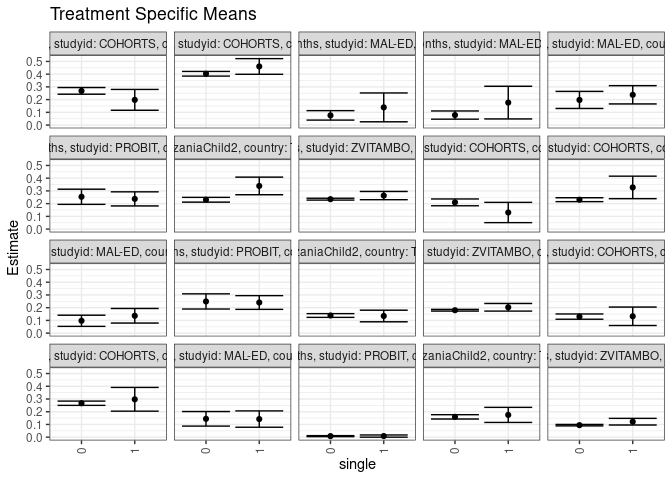

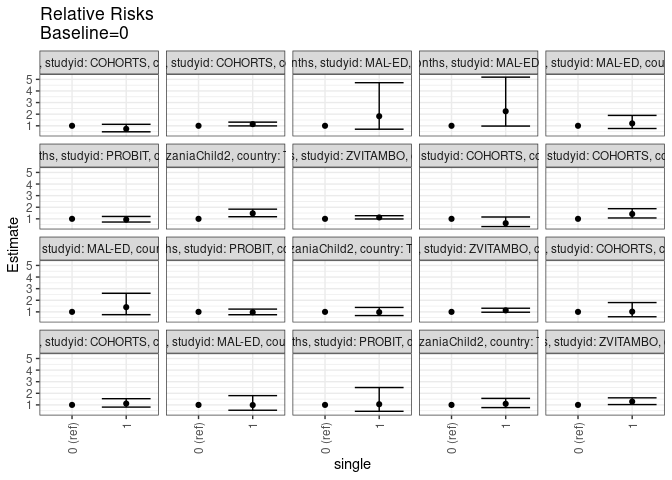

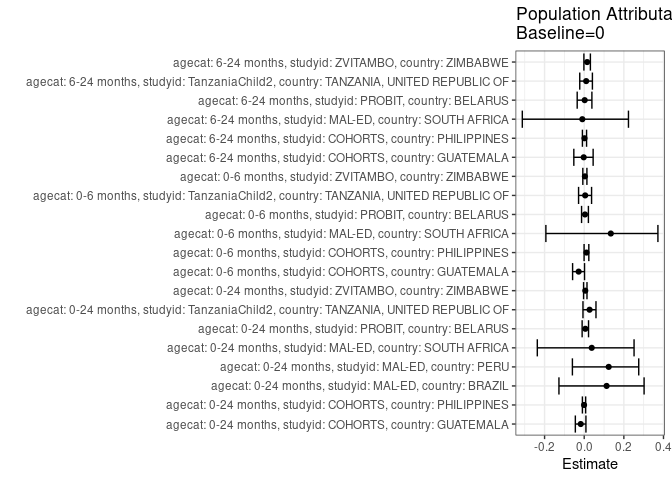

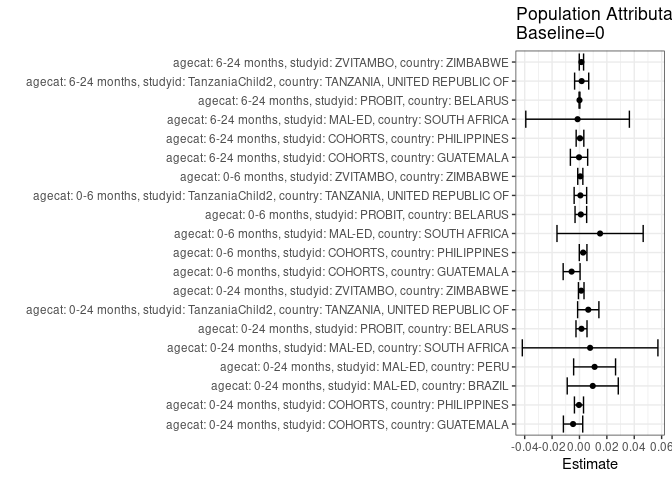

## Results Table

### Parameter: TSM

| agecat | studyid | country | intervention_level | baseline_level | estimate | ci_lower | ci_upper |
| --- | --- | --- | --- | --- | --- | --- | --- |
| 0-24 months | COHORTS | GUATEMALA | 0 | NA | 0.2686692 | 0.2424572 | 0.2948812 |
| 0-24 months | COHORTS | GUATEMALA | 1 | NA | 0.1980860 | 0.1161472 | 0.2800248 |
| 0-24 months | COHORTS | PHILIPPINES | 0 | NA | 0.4030226 | 0.3847947 | 0.4212506 |
| 0-24 months | COHORTS | PHILIPPINES | 1 | NA | 0.4604620 | 0.3989346 | 0.5219894 |
| 0-24 months | MAL-ED | BRAZIL | 0 | NA | 0.0761421 | 0.0390259 | 0.1132584 |
| 0-24 months | MAL-ED | BRAZIL | 1 | NA | 0.1388889 | 0.0256764 | 0.2521013 |
| 0-24 months | MAL-ED | PERU | 0 | NA | 0.0783582 | 0.0461309 | 0.1105855 |
| 0-24 months | MAL-ED | PERU | 1 | NA | 0.1764706 | 0.0481180 | 0.3048232 |
| 0-24 months | MAL-ED | SOUTH AFRICA | 0 | NA | 0.1973560 | 0.1303001 | 0.2644119 |
| 0-24 months | MAL-ED | SOUTH AFRICA | 1 | NA | 0.2376923 | 0.1659361 | 0.3094486 |
| 0-24 months | PROBIT | BELARUS | 0 | NA | 0.2539378 | 0.1944224 | 0.3134532 |
| 0-24 months | PROBIT | BELARUS | 1 | NA | 0.2374138 | 0.1819823 | 0.2928453 |
| 0-24 months | TanzaniaChild2 | TANZANIA, UNITED REPUBLIC OF | 0 | NA | 0.2306320 | 0.2118565 | 0.2494074 |
| 0-24 months | TanzaniaChild2 | TANZANIA, UNITED REPUBLIC OF | 1 | NA | 0.3391255 | 0.2700035 | 0.4082476 |
| 0-24 months | ZVITAMBO | ZIMBABWE | 0 | NA | 0.2351463 | 0.2278177 | 0.2424750 |
| 0-24 months | ZVITAMBO | ZIMBABWE | 1 | NA | 0.2632977 | 0.2308891 | 0.2957063 |
| 0-6 months | COHORTS | GUATEMALA | 0 | NA | 0.2101124 | 0.1833337 | 0.2368910 |
| 0-6 months | COHORTS | GUATEMALA | 1 | NA | 0.1304348 | 0.0509292 | 0.2099404 |
| 0-6 months | COHORTS | PHILIPPINES | 0 | NA | 0.2310286 | 0.2156506 | 0.2464065 |
| 0-6 months | COHORTS | PHILIPPINES | 1 | NA | 0.3274857 | 0.2391841 | 0.4157873 |
| 0-6 months | MAL-ED | SOUTH AFRICA | 0 | NA | 0.0971262 | 0.0533587 | 0.1408938 |
| 0-6 months | MAL-ED | SOUTH AFRICA | 1 | NA | 0.1364710 | 0.0791757 | 0.1937663 |
| 0-6 months | PROBIT | BELARUS | 0 | NA | 0.2490085 | 0.1893079 | 0.3087090 |
| 0-6 months | PROBIT | BELARUS | 1 | NA | 0.2406348 | 0.1867545 | 0.2945151 |
| 0-6 months | TanzaniaChild2 | TANZANIA, UNITED REPUBLIC OF | 0 | NA | 0.1386910 | 0.1240751 | 0.1533069 |
| 0-6 months | TanzaniaChild2 | TANZANIA, UNITED REPUBLIC OF | 1 | NA | 0.1347006 | 0.0891621 | 0.1802390 |
| 0-6 months | ZVITAMBO | ZIMBABWE | 0 | NA | 0.1800887 | 0.1734216 | 0.1867559 |
| 0-6 months | ZVITAMBO | ZIMBABWE | 1 | NA | 0.2030910 | 0.1729963 | 0.2331858 |
| 6-24 months | COHORTS | GUATEMALA | 0 | NA | 0.1299408 | 0.1091225 | 0.1507590 |
| 6-24 months | COHORTS | GUATEMALA | 1 | NA | 0.1324069 | 0.0599796 | 0.2048342 |
| 6-24 months | COHORTS | PHILIPPINES | 0 | NA | 0.2666477 | 0.2498822 | 0.2834133 |
| 6-24 months | COHORTS | PHILIPPINES | 1 | NA | 0.2974647 | 0.2042382 | 0.3906912 |
| 6-24 months | MAL-ED | SOUTH AFRICA | 0 | NA | 0.1442304 | 0.0869365 | 0.2015243 |
| 6-24 months | MAL-ED | SOUTH AFRICA | 1 | NA | 0.1422680 | 0.0779764 | 0.2065596 |
| 6-24 months | PROBIT | BELARUS | 0 | NA | 0.0083548 | 0.0044070 | 0.0123026 |
| 6-24 months | PROBIT | BELARUS | 1 | NA | 0.0088365 | 0.0002568 | 0.0174162 |
| 6-24 months | TanzaniaChild2 | TANZANIA, UNITED REPUBLIC OF | 0 | NA | 0.1596607 | 0.1428492 | 0.1764722 |
| 6-24 months | TanzaniaChild2 | TANZANIA, UNITED REPUBLIC OF | 1 | NA | 0.1748972 | 0.1156814 | 0.2341130 |
| 6-24 months | ZVITAMBO | ZIMBABWE | 0 | NA | 0.0945702 | 0.0888611 | 0.1002792 |
| 6-24 months | ZVITAMBO | ZIMBABWE | 1 | NA | 0.1217931 | 0.0956253 | 0.1479609 |

### Parameter: E(Y)

| agecat | studyid | country | intervention_level | baseline_level | estimate | ci_lower | ci_upper |
| --- | --- | --- | --- | --- | --- | --- | --- |
| 0-24 months | COHORTS | GUATEMALA | NA | NA | 0.2639933 | 0.2390117 | 0.2889749 |
| 0-24 months | COHORTS | PHILIPPINES | NA | NA | 0.4026622 | 0.3851243 | 0.4202002 |
| 0-24 months | MAL-ED | BRAZIL | NA | NA | 0.0858369 | 0.0497913 | 0.1218826 |
| 0-24 months | MAL-ED | PERU | NA | NA | 0.0894040 | 0.0571706 | 0.1216374 |
| 0-24 months | MAL-ED | SOUTH AFRICA | NA | NA | 0.2051282 | 0.1602507 | 0.2500058 |
| 0-24 months | PROBIT | BELARUS | NA | NA | 0.2554148 | 0.1971257 | 0.3137039 |
| 0-24 months | TanzaniaChild2 | TANZANIA, UNITED REPUBLIC OF | NA | NA | 0.2370526 | 0.2199455 | 0.2541598 |
| 0-24 months | ZVITAMBO | ZIMBABWE | NA | NA | 0.2364291 | 0.2293629 | 0.2434953 |
| 0-6 months | COHORTS | GUATEMALA | NA | NA | 0.2043796 | 0.1788445 | 0.2299146 |
| 0-6 months | COHORTS | PHILIPPINES | NA | NA | 0.2336884 | 0.2185531 | 0.2488237 |
| 0-6 months | MAL-ED | SOUTH AFRICA | NA | NA | 0.1121795 | 0.0771053 | 0.1472536 |
| 0-6 months | PROBIT | BELARUS | NA | NA | 0.2500148 | 0.1915461 | 0.3084835 |
| 0-6 months | TanzaniaChild2 | TANZANIA, UNITED REPUBLIC OF | NA | NA | 0.1393684 | 0.1254369 | 0.1532999 |
| 0-6 months | ZVITAMBO | ZIMBABWE | NA | NA | 0.1806915 | 0.1742710 | 0.1871119 |
| 6-24 months | COHORTS | GUATEMALA | NA | NA | 0.1296130 | 0.1098539 | 0.1493721 |
| 6-24 months | COHORTS | PHILIPPINES | NA | NA | 0.2670270 | 0.2505637 | 0.2834903 |
| 6-24 months | MAL-ED | SOUTH AFRICA | NA | NA | 0.1428571 | 0.1001583 | 0.1855560 |
| 6-24 months | PROBIT | BELARUS | NA | NA | 0.0083745 | 0.0044130 | 0.0123360 |
| 6-24 months | TanzaniaChild2 | TANZANIA, UNITED REPUBLIC OF | NA | NA | 0.1612581 | 0.1451483 | 0.1773679 |
| 6-24 months | ZVITAMBO | ZIMBABWE | NA | NA | 0.0959985 | 0.0904349 | 0.1015621 |

### Parameter: RR

| agecat | studyid | country | intervention_level | baseline_level | estimate | ci_lower | ci_upper |
| --- | --- | --- | --- | --- | --- | --- | --- |
| 0-24 months | COHORTS | GUATEMALA | 0 | 0 | 1.0000000 | 1.0000000 | 1.000000 |
| 0-24 months | COHORTS | GUATEMALA | 1 | 0 | 0.7372859 | 0.4820733 | 1.127610 |
| 0-24 months | COHORTS | PHILIPPINES | 0 | 0 | 1.0000000 | 1.0000000 | 1.000000 |
| 0-24 months | COHORTS | PHILIPPINES | 1 | 0 | 1.1425215 | 0.9922143 | 1.315598 |
| 0-24 months | MAL-ED | BRAZIL | 0 | 0 | 1.0000000 | 1.0000000 | 1.000000 |
| 0-24 months | MAL-ED | BRAZIL | 1 | 0 | 1.8240741 | 0.7056101 | 4.715418 |
| 0-24 months | MAL-ED | PERU | 0 | 0 | 1.0000000 | 1.0000000 | 1.000000 |
| 0-24 months | MAL-ED | PERU | 1 | 0 | 2.2521008 | 0.9765802 | 5.193591 |
| 0-24 months | MAL-ED | SOUTH AFRICA | 0 | 0 | 1.0000000 | 1.0000000 | 1.000000 |
| 0-24 months | MAL-ED | SOUTH AFRICA | 1 | 0 | 1.2043838 | 0.7650202 | 1.896081 |
| 0-24 months | PROBIT | BELARUS | 0 | 0 | 1.0000000 | 1.0000000 | 1.000000 |
| 0-24 months | PROBIT | BELARUS | 1 | 0 | 0.9349291 | 0.7257307 | 1.204431 |
| 0-24 months | TanzaniaChild2 | TANZANIA, UNITED REPUBLIC OF | 0 | 0 | 1.0000000 | 1.0000000 | 1.000000 |
| 0-24 months | TanzaniaChild2 | TANZANIA, UNITED REPUBLIC OF | 1 | 0 | 1.4704185 | 1.1807845 | 1.831097 |
| 0-24 months | ZVITAMBO | ZIMBABWE | 0 | 0 | 1.0000000 | 1.0000000 | 1.000000 |
| 0-24 months | ZVITAMBO | ZIMBABWE | 1 | 0 | 1.1197184 | 0.9862862 | 1.271202 |
| 0-6 months | COHORTS | GUATEMALA | 0 | 0 | 1.0000000 | 1.0000000 | 1.000000 |
| 0-6 months | COHORTS | GUATEMALA | 1 | 0 | 0.6207859 | 0.3330396 | 1.157145 |
| 0-6 months | COHORTS | PHILIPPINES | 0 | 0 | 1.0000000 | 1.0000000 | 1.000000 |
| 0-6 months | COHORTS | PHILIPPINES | 1 | 0 | 1.4175118 | 1.0737511 | 1.871327 |
| 0-6 months | MAL-ED | SOUTH AFRICA | 0 | 0 | 1.0000000 | 1.0000000 | 1.000000 |
| 0-6 months | MAL-ED | SOUTH AFRICA | 1 | 0 | 1.4050889 | 0.7585517 | 2.602690 |
| 0-6 months | PROBIT | BELARUS | 0 | 0 | 1.0000000 | 1.0000000 | 1.000000 |
| 0-6 months | PROBIT | BELARUS | 1 | 0 | 0.9663720 | 0.7531453 | 1.239966 |
| 0-6 months | TanzaniaChild2 | TANZANIA, UNITED REPUBLIC OF | 0 | 0 | 1.0000000 | 1.0000000 | 1.000000 |
| 0-6 months | TanzaniaChild2 | TANZANIA, UNITED REPUBLIC OF | 1 | 0 | 0.9712278 | 0.6816010 | 1.383923 |
| 0-6 months | ZVITAMBO | ZIMBABWE | 0 | 0 | 1.0000000 | 1.0000000 | 1.000000 |
| 0-6 months | ZVITAMBO | ZIMBABWE | 1 | 0 | 1.1277278 | 0.9679985 | 1.313814 |
| 6-24 months | COHORTS | GUATEMALA | 0 | 0 | 1.0000000 | 1.0000000 | 1.000000 |
| 6-24 months | COHORTS | GUATEMALA | 1 | 0 | 1.0189791 | 0.5763483 | 1.801546 |
| 6-24 months | COHORTS | PHILIPPINES | 0 | 0 | 1.0000000 | 1.0000000 | 1.000000 |
| 6-24 months | COHORTS | PHILIPPINES | 1 | 0 | 1.1155718 | 0.8104222 | 1.535620 |
| 6-24 months | MAL-ED | SOUTH AFRICA | 0 | 0 | 1.0000000 | 1.0000000 | 1.000000 |
| 6-24 months | MAL-ED | SOUTH AFRICA | 1 | 0 | 0.9863938 | 0.5402598 | 1.800935 |
| 6-24 months | PROBIT | BELARUS | 0 | 0 | 1.0000000 | 1.0000000 | 1.000000 |
| 6-24 months | PROBIT | BELARUS | 1 | 0 | 1.0576589 | 0.4478582 | 2.497760 |
| 6-24 months | TanzaniaChild2 | TANZANIA, UNITED REPUBLIC OF | 0 | 0 | 1.0000000 | 1.0000000 | 1.000000 |
| 6-24 months | TanzaniaChild2 | TANZANIA, UNITED REPUBLIC OF | 1 | 0 | 1.0954307 | 0.7686178 | 1.561203 |
| 6-24 months | ZVITAMBO | ZIMBABWE | 0 | 0 | 1.0000000 | 1.0000000 | 1.000000 |
| 6-24 months | ZVITAMBO | ZIMBABWE | 1 | 0 | 1.2878595 | 1.0303932 | 1.609659 |

### Parameter: PAR

| agecat | studyid | country | intervention_level | baseline_level | estimate | ci_lower | ci_upper |
| --- | --- | --- | --- | --- | --- | --- | --- |
| 0-24 months | COHORTS | GUATEMALA | 0 | NA | -0.0046759 | -0.0117310 | 0.0023792 |
| 0-24 months | COHORTS | PHILIPPINES | 0 | NA | -0.0003604 | -0.0036780 | 0.0029572 |
| 0-24 months | MAL-ED | BRAZIL | 0 | NA | 0.0096948 | -0.0089432 | 0.0283328 |
| 0-24 months | MAL-ED | PERU | 0 | NA | 0.0110458 | -0.0042594 | 0.0263510 |
| 0-24 months | MAL-ED | SOUTH AFRICA | 0 | NA | 0.0077722 | -0.0417351 | 0.0572795 |
| 0-24 months | PROBIT | BELARUS | 0 | NA | 0.0014771 | -0.0025492 | 0.0055033 |
| 0-24 months | TanzaniaChild2 | TANZANIA, UNITED REPUBLIC OF | 0 | NA | 0.0064206 | -0.0013459 | 0.0141872 |
| 0-24 months | ZVITAMBO | ZIMBABWE | 0 | NA | 0.0012827 | -0.0007499 | 0.0033154 |
| 0-6 months | COHORTS | GUATEMALA | 0 | NA | -0.0057328 | -0.0119082 | 0.0004426 |
| 0-6 months | COHORTS | PHILIPPINES | 0 | NA | 0.0026598 | -0.0001252 | 0.0054449 |
| 0-6 months | MAL-ED | SOUTH AFRICA | 0 | NA | 0.0150532 | -0.0164152 | 0.0465216 |
| 0-6 months | PROBIT | BELARUS | 0 | NA | 0.0010063 | -0.0032337 | 0.0052464 |
| 0-6 months | TanzaniaChild2 | TANZANIA, UNITED REPUBLIC OF | 0 | NA | 0.0006774 | -0.0038919 | 0.0052467 |
| 0-6 months | ZVITAMBO | ZIMBABWE | 0 | NA | 0.0006027 | -0.0012579 | 0.0024634 |
| 6-24 months | COHORTS | GUATEMALA | 0 | NA | -0.0003278 | -0.0066388 | 0.0059832 |
| 6-24 months | COHORTS | PHILIPPINES | 0 | NA | 0.0003793 | -0.0024182 | 0.0031768 |
| 6-24 months | MAL-ED | SOUTH AFRICA | 0 | NA | -0.0013733 | -0.0391974 | 0.0364508 |
| 6-24 months | PROBIT | BELARUS | 0 | NA | 0.0000197 | -0.0002915 | 0.0003309 |
| 6-24 months | TanzaniaChild2 | TANZANIA, UNITED REPUBLIC OF | 0 | NA | 0.0015974 | -0.0035530 | 0.0067479 |
| 6-24 months | ZVITAMBO | ZIMBABWE | 0 | NA | 0.0014283 | -0.0001449 | 0.0030015 |

### Parameter: PAF

| agecat | studyid | country | intervention_level | baseline_level | estimate | ci_lower | ci_upper |
| --- | --- | --- | --- | --- | --- | --- | --- |
| 0-24 months | COHORTS | GUATEMALA | 0 | NA | -0.0177121 | -0.0447800 | 0.0086545 |
| 0-24 months | COHORTS | PHILIPPINES | 0 | NA | -0.0008950 | -0.0091637 | 0.0073059 |
| 0-24 months | MAL-ED | BRAZIL | 0 | NA | 0.1129442 | -0.1275143 | 0.3021215 |
| 0-24 months | MAL-ED | PERU | 0 | NA | 0.1235489 | -0.0596047 | 0.2750443 |
| 0-24 months | MAL-ED | SOUTH AFRICA | 0 | NA | 0.0378897 | -0.2366865 | 0.2515029 |
| 0-24 months | PROBIT | BELARUS | 0 | NA | 0.0057830 | -0.0105233 | 0.0218261 |
| 0-24 months | TanzaniaChild2 | TANZANIA, UNITED REPUBLIC OF | 0 | NA | 0.0270853 | -0.0062922 | 0.0593557 |
| 0-24 months | ZVITAMBO | ZIMBABWE | 0 | NA | 0.0054255 | -0.0032085 | 0.0139852 |
| 0-6 months | COHORTS | GUATEMALA | 0 | NA | -0.0280498 | -0.0586145 | 0.0016325 |
| 0-6 months | COHORTS | PHILIPPINES | 0 | NA | 0.0113820 | -0.0006278 | 0.0232477 |
| 0-6 months | MAL-ED | SOUTH AFRICA | 0 | NA | 0.1341889 | -0.1934202 | 0.3718651 |
| 0-6 months | PROBIT | BELARUS | 0 | NA | 0.0040251 | -0.0133503 | 0.0211026 |
| 0-6 months | TanzaniaChild2 | TANZANIA, UNITED REPUBLIC OF | 0 | NA | 0.0048605 | -0.0284698 | 0.0371105 |
| 0-6 months | ZVITAMBO | ZIMBABWE | 0 | NA | 0.0033357 | -0.0070148 | 0.0135798 |
| 6-24 months | COHORTS | GUATEMALA | 0 | NA | -0.0025290 | -0.0524181 | 0.0449952 |
| 6-24 months | COHORTS | PHILIPPINES | 0 | NA | 0.0014204 | -0.0091138 | 0.0118447 |
| 6-24 months | MAL-ED | SOUTH AFRICA | 0 | NA | -0.0096129 | -0.3123309 | 0.2232765 |
| 6-24 months | PROBIT | BELARUS | 0 | NA | 0.0023532 | -0.0354342 | 0.0387615 |
| 6-24 months | TanzaniaChild2 | TANZANIA, UNITED REPUBLIC OF | 0 | NA | 0.0099060 | -0.0225486 | 0.0413305 |
| 6-24 months | ZVITAMBO | ZIMBABWE | 0 | NA | 0.0148787 | -0.0016274 | 0.0311128 |